# PSTAT 131 Homework 1

### Exercise 4:

*Box plot of `hwy` grouped by `cyl`*

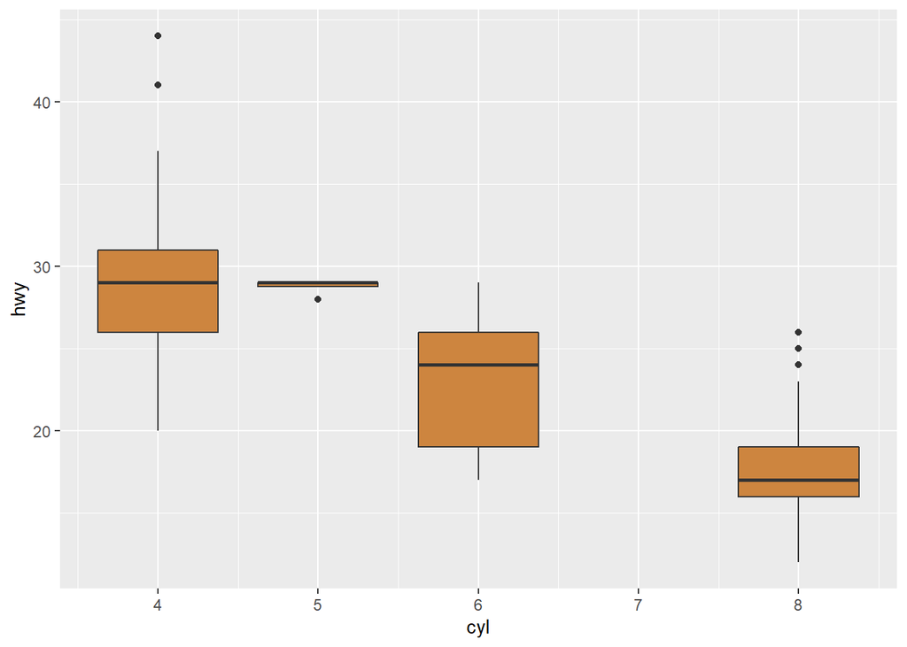

```r
# creating box plot of hwy and grouping it with cyl
box <- ggplot(data = mpg, aes(x = cyl, y = hwy)) + geom_boxplot(aes(group = cyl), fill = 'tan3')
box
```

The boxplot shows a pattern of increasing mpg on highways as there are less cylinders.

### Exercise 5:

*Lower triangle correlation matrix of `mpg` with numerical variables `hwy`, `cyl`, `displ`, `cty`*

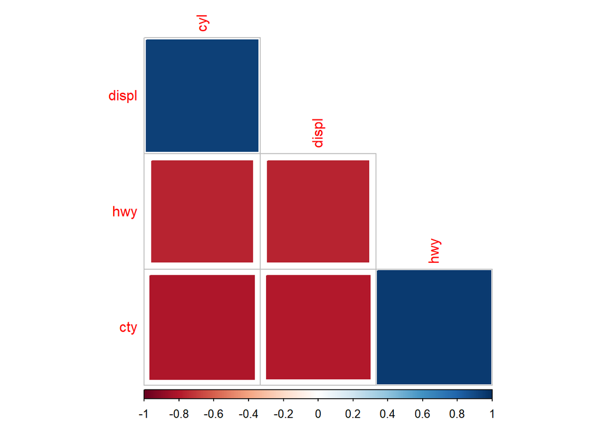

```r
var <- c('hwy', 'cyl', 'displ', 'cty') # selecting variables without categorical values
M <- cor(mpg[var])
corrplot(M, method = 'square', order = 'FPC', type = 'lower', diag = FALSE) # creating the diagonal plot
```

The color bar shows that red implies a negative correlation and blue implies a positive correlation. It shows that `hwy` and `displ`, `hwy` and `cyl`, `cty` and `cyl`, `cty` and `displ` are negatively correlated while `cty` and `hwy`, `displ` and `cyl` are positively correlated. These relationships are expected since we saw the relationship between `hwy` and `cyl` in problem 4, so it is not surprising that the amount of cylinders would decrease mpg in the city and highway. Similarly, displacement would act the same as cylinders, causing a negative correlation between mpg in highway and city. This can be said in the other way as well.